# Cyclisitic Bike-Share Analytics Project

Yifan Zhao

2023-09-21

## Scenario

Suppose you are a junior data analyst working for a fictional company, Cyclistic which is a bike-share company in Chicago. The director of marketing believes the company’s future success depends on maximizing the number of annual memberships. Therefore, our goal is to design a new marketing strategy to convert casual riders into annual members. Before that, we need to understand how casual riders and annual members use Cyclistic bikes differently.

I will use six steps analysis process to deal with this problem, including Ask, Prepare, Process, Analyze, Share and Act.

## Ask

Three questions will guide us through future analysis:

- How do annual members and casual riders use our Cyclistic bikes differently?
- Why would casual members buy Cyclistic annual memberships?
- How can Cyclistic use digital media to influence casual riders to become members?

## Process

Since this is a large dataset, with 5,779,444 rows, I choose RStudio to process data.

### Install packages

```r
#install.packages("tidyverse")
#install.packages("ggplot2")
#install.packages("janitor")
#install.packages('lubridate')

library("janitor")
library('tidyverse')
library('ggplot2')
library('lubridate')
```

### Import Data

```r
Jul2022 <- read_csv("/Users/ivanazhao/Desktop/Coursera/Google Analytics/Capstone Project/monthly_trip_data/2022_07.csv")
Aug2022 <- read_csv("/Users/ivanazhao/Desktop/Coursera/Google Analytics/Capstone Project/monthly_trip_data/2022_08.csv")
Sep2022 <- read_csv("/Users/ivanazhao/Desktop/Coursera/Google Analytics/Capstone Project/monthly_trip_data/2022_09.csv")
Oct2022 <- read_csv("/Users/ivanazhao/Desktop/Coursera/Google Analytics/Capstone Project/monthly_trip_data/2022_10.csv")
Nov2022 <- read_csv("/Users/ivanazhao/Desktop/Coursera/Google Analytics/Capstone Project/monthly_trip_data/2022_11.csv")
Dec2022 <- read_csv("/Users/ivanazhao/Desktop/Coursera/Google Analytics/Capstone Project/monthly_trip_data/2022_12.csv")
Jan2023 <- read_csv("/Users/ivanazhao/Desktop/Coursera/Google Analytics/Capstone Project/monthly_trip_data/2023_01.csv")
Feb2023 <- read_csv("/Users/ivanazhao/Desktop/Coursera/Google Analytics/Capstone Project/monthly_trip_data/2023_02.csv")
Mar2023 <- read_csv("/Users/ivanazhao/Desktop/Coursera/Google Analytics/Capstone Project/monthly_trip_data/2023_03.csv")
Apr2023 <- read_csv("/Users/ivanazhao/Desktop/Coursera/Google Analytics/Capstone Project/monthly_trip_data/2023_04.csv")
May2023 <- read_csv("/Users/ivanazhao/Desktop/Coursera/Google Analytics/Capstone Project/monthly_trip_data/2023_05.csv")
Jun2023 <- read_csv("/Users/ivanazhao/Desktop/Coursera/Google Analytics/Capstone Project/monthly_trip_data/2023_06.csv")
str(Jul2022)
```

```
## spc_tbl_ [823,488 × 13] (S3: spec_tbl_df/tbl_df/tbl/data.frame)
##  $ ride_id           : chr [1:823488] "954144C2F67B1932" "292E027607D218B6" "57765852588AD6E0" "B5B6BE44314590E6" ...
##  $ rideable_type     : chr [1:823488] "classic_bike" "classic_bike" "classic_bike" "classic_bike" ...
##  $ started_at        : POSIXct[1:823488], format: "2022-07-05 08:12:47" "2022-07-26 12:53:38" ...
##  $ ended_at          : POSIXct[1:823488], format: "2022-07-05 08:24:32" "2022-07-26 12:55:31" ...
##  $ start_station_name: chr [1:823488] "Ashland Ave & Blackhawk St" "Buckingham Fountain (Temp)" "Buckingham Fountain (Temp)" "Buckingham Fountain (Temp)" ...
##  $ start_station_id  : chr [1:823488] "13224" "15541" "15541" "15541" ...
##  $ end_station_name  : chr [1:823488] "Kingsbury St & Kinzie St" "Michigan Ave & 8th St" "Michigan Ave & 8th St" "Woodlawn Ave & 55th St" ...
##  $ end_station_id    : chr [1:823488] "KA1503000043" "623" "623" "TA1307000164" ...
##  $ start_lat         : num [1:823488] 41.9 41.9 41.9 41.9 41.9 ...
##  $ start_lng         : num [1:823488] -87.7 -87.6 -87.6 -87.6 -87.6 ...
##  $ end_lat           : num [1:823488] 41.9 41.9 41.9 41.8 41.9 ...
##  $ end_lng           : num [1:823488] -87.6 -87.6 -87.6 -87.6 -87.7 ...
##  $ member_casual     : chr [1:823488] "member" "casual" "casual" "casual" ...
##  - attr(*, "spec")=
##   .. cols(
##   ..   ride_id = col_character(),
##   ..   rideable_type = col_character(),
##   ..   started_at = col_datetime(format = ""),
##   ..   ended_at = col_datetime(format = ""),
##   ..   start_station_name = col_character(),
##   ..   start_station_id = col_character(),
##   ..   end_station_name = col_character(),
##   ..   end_station_id = col_character(),
##   ..   start_lat = col_double(),
##   ..   start_lng = col_double(),
##   ..   end_lat = col_double(),
##   ..   end_lng = col_double(),
##   ..   member_casual = col_character()
##   .. )
##  - attr(*, "problems")=<externalptr>
```

```r
str(Aug2022)
```

```
## spc_tbl_ [785,932 × 13] (S3: spec_tbl_df/tbl_df/tbl/data.frame)
##  $ ride_id           : chr [1:785932] "550CF7EFEAE0C618" "DAD198F405F9C5F5" "E6F2BC47B65CB7FD" "F597830181C2E13C" ...
##  $ rideable_type     : chr [1:785932] "electric_bike" "electric_bike" "electric_bike" "electric_bike" ...
##  $ started_at        : POSIXct[1:785932], format: "2022-08-07 21:34:15" "2022-08-08 14:39:21" ...
##  $ ended_at          : POSIXct[1:785932], format: "2022-08-07 21:41:46" "2022-08-08 14:53:23" ...
##  $ start_station_name: chr [1:785932] NA NA NA NA ...
##  $ start_station_id  : chr [1:785932] NA NA NA NA ...
##  $ end_station_name  : chr [1:785932] NA NA NA NA ...
##  $ end_station_id    : chr [1:785932] NA NA NA NA ...
##  $ start_lat         : num [1:785932] 41.9 41.9 42 41.9 41.9 ...
##  $ start_lng         : num [1:785932] -87.7 -87.6 -87.7 -87.7 -87.7 ...
##  $ end_lat           : num [1:785932] 41.9 41.9 42 42 41.8 ...
##  $ end_lng           : num [1:785932] -87.7 -87.6 -87.7 -87.7 -87.7 ...
##  $ member_casual     : chr [1:785932] "casual" "casual" "casual" "casual" ...
##  - attr(*, "spec")=
##   .. cols(
##   ..   ride_id = col_character(),
##   ..   rideable_type = col_character(),
##   ..   started_at = col_datetime(format = ""),
##   ..   ended_at = col_datetime(format = ""),
##   ..   start_station_name = col_character(),
##   ..   start_station_id = col_character(),
##   ..   end_station_name = col_character(),
##   ..   end_station_id = col_character(),
##   ..   start_lat = col_double(),
##   ..   start_lng = col_double(),
##   ..   end_lat = col_double(),
##   ..   end_lng = col_double(),
##   ..   member_casual = col_character()
##   .. )
##  - attr(*, "problems")=<externalptr>
```

**After analyzing data structures, we noticed those datasets have exactly the same structure, so we decided to join them together**

### Merge and Clean Datasets

```r
df <- bind_rows(Jul2022, Aug2022, Sep2022, Oct2022, Nov2022, Dec2022, Jan2023, Feb2023, Mar2023, Apr2023, May2023, Jun2023)

head(df)
```

```
## # A tibble: 6 × 13
##   ride_id          rideable_type started_at          ended_at
##   <chr>            <chr>         <dttm>              <dttm>
## 1 954144C2F67B1932 classic_bike  2022-07-05 08:12:47 2022-07-05 08:24:32
## 2 292E027607D218B6 classic_bike  2022-07-26 12:53:38 2022-07-26 12:55:31
## 3 57765852588AD6E0 classic_bike  2022-07-03 13:58:49 2022-07-03 14:06:32
## 4 B5B6BE44314590E6 classic_bike  2022-07-31 17:44:21 2022-07-31 18:42:50
## 5 A4C331F2A00E79E0 classic_bike  2022-07-13 19:49:06 2022-07-13 20:15:24
## 6 579D73BE2ED880B3 electric_bike 2022-07-01 17:04:35 2022-07-01 17:13:18
## # ℹ 9 more variables: start_station_name <chr>, start_station_id <chr>,
## #   end_station_name <chr>, end_station_id <chr>, start_lat <dbl>,
## #   start_lng <dbl>, end_lat <dbl>, end_lng <dbl>, member_casual <chr>
```

```r
str(df)
```

```
## spc_tbl_ [5,779,444 × 13] (S3: spec_tbl_df/tbl_df/tbl/data.frame)
##  $ ride_id           : chr [1:5779444] "954144C2F67B1932" "292E027607D218B6" "57765852588AD6E0" "B5B6BE44314590E6" ...
##  $ rideable_type     : chr [1:5779444] "classic_bike" "classic_bike" "classic_bike" "classic_bike" ...
##  $ started_at        : POSIXct[1:5779444], format: "2022-07-05 08:12:47" "2022-07-26 12:53:38" ...
##  $ ended_at          : POSIXct[1:5779444], format: "2022-07-05 08:24:32" "2022-07-26 12:55:31" ...
##  $ start_station_name: chr [1:5779444] "Ashland Ave & Blackhawk St" "Buckingham Fountain (Temp)" "Buckingham Fountain (Temp)" "Buckingham Fountain (Temp)" ...
##  $ start_station_id  : chr [1:5779444] "13224" "15541" "15541" "15541" ...
##  $ end_station_name  : chr [1:5779444] "Kingsbury St & Kinzie St" "Michigan Ave & 8th St" "Michigan Ave & 8th St" "Woodlawn Ave & 55th St" ...
##  $ end_station_id    : chr [1:5779444] "KA1503000043" "623" "623" "TA1307000164" ...
##  $ start_lat         : num [1:5779444] 41.9 41.9 41.9 41.9 41.9 ...
##  $ start_lng         : num [1:5779444] -87.7 -87.6 -87.6 -87.6 -87.6 ...
##  $ end_lat           : num [1:5779444] 41.9 41.9 41.9 41.8 41.9 ...
##  $ end_lng           : num [1:5779444] -87.6 -87.6 -87.6 -87.6 -87.7 ...
##  $ member_casual     : chr [1:5779444] "member" "casual" "casual" "casual" ...
##  - attr(*, "spec")=
##   .. cols(
##   ..   ride_id = col_character(),
##   ..   rideable_type = col_character(),
##   ..   started_at = col_datetime(format = ""),
##   ..   ended_at = col_datetime(format = ""),
##   ..   start_station_name = col_character(),
##   ..   start_station_id = col_character(),
##   ..   end_station_name = col_character(),
##   ..   end_station_id = col_character(),
##   ..   start_lat = col_double(),
##   ..   start_lng = col_double(),
##   ..   end_lat = col_double(),
##   ..   end_lng = col_double(),
##   ..   member_casual = col_character()
##   .. )
##  - attr(*, "problems")=<externalptr>
```

```r
# Clean column names
clean_names(df)
```

```
## # A tibble: 5,779,444 × 13
##    ride_id          rideable_type started_at          ended_at
##    <chr>            <chr>         <dttm>              <dttm>
##  1 954144C2F67B1932 classic_bike  2022-07-05 08:12:47 2022-07-05 08:24:32
##  2 292E027607D218B6 classic_bike  2022-07-26 12:53:38 2022-07-26 12:55:31
##  3 57765852588AD6E0 classic_bike  2022-07-03 13:58:49 2022-07-03 14:06:32
##  4 B5B6BE44314590E6 classic_bike  2022-07-31 17:44:21 2022-07-31 18:42:50
##  5 A4C331F2A00E79E0 classic_bike  2022-07-13 19:49:06 2022-07-13 20:15:24
##  6 579D73BE2ED880B3 electric_bike 2022-07-01 17:04:35 2022-07-01 17:13:18
##  7 EFE518CCEE333669 classic_bike  2022-07-18 18:11:01 2022-07-18 18:22:30
##  8 315FEBB7B3F6D2EA classic_bike  2022-07-28 20:38:18 2022-07-28 21:09:11
##  9 EE3C4A1E66766B56 classic_bike  2022-07-10 22:55:59 2022-07-10 23:01:32
## 10 1EE6C93A547A187C electric_bike 2022-07-10 09:35:58 2022-07-10 09:47:25
## # ℹ 5,779,434 more rows
## # ℹ 9 more variables: start_station_name <chr>, start_station_id <chr>,
## #   end_station_name <chr>, end_station_id <chr>, start_lat <dbl>,
## #   start_lng <dbl>, end_lat <dbl>, end_lng <dbl>, member_casual <chr>
```

```r
# Remove empty rows and columns
remove_empty(df, which=c())
```

```
## # A tibble: 5,779,444 × 13
##    ride_id          rideable_type started_at          ended_at
##    <chr>            <chr>         <dttm>              <dttm>
##  1 954144C2F67B1932 classic_bike  2022-07-05 08:12:47 2022-07-05 08:24:32
##  2 292E027607D218B6 classic_bike  2022-07-26 12:53:38 2022-07-26 12:55:31
##  3 57765852588AD6E0 classic_bike  2022-07-03 13:58:49 2022-07-03 14:06:32
##  4 B5B6BE44314590E6 classic_bike  2022-07-31 17:44:21 2022-07-31 18:42:50
##  5 A4C331F2A00E79E0 classic_bike  2022-07-13 19:49:06 2022-07-13 20:15:24
##  6 579D73BE2ED880B3 electric_bike 2022-07-01 17:04:35 2022-07-01 17:13:18
##  7 EFE518CCEE333669 classic_bike  2022-07-18 18:11:01 2022-07-18 18:22:30
##  8 315FEBB7B3F6D2EA classic_bike  2022-07-28 20:38:18 2022-07-28 21:09:11
##  9 EE3C4A1E66766B56 classic_bike  2022-07-10 22:55:59 2022-07-10 23:01:32
## 10 1EE6C93A547A187C electric_bike 2022-07-10 09:35:58 2022-07-10 09:47:25
## # ℹ 5,779,434 more rows
## # ℹ 9 more variables: start_station_name <chr>, start_station_id <chr>,
## #   end_station_name <chr>, end_station_id <chr>, start_lat <dbl>,
## #   start_lng <dbl>, end_lat <dbl>, end_lng <dbl>, member_casual <chr>
```

### Add New Columns

```r
# Calculate length of each ride
df <- df %>%
        mutate(ride_length = (ended_at - started_at)/60)

# Remove rows with negative ride_length values
df <- df[df$ride_length >= 0, ]

# Create column "day_of_week"
df <- df %>%
        mutate(day_of_week = wday(started_at))

# Create column "month"
df <- df %>%
        mutate(month = format(as.Date(started_at), "%m"))

# Change data type
df$ride_length <- as.numeric(df$ride_length)
df$month <- as.numeric(df$month)
df$day_of_week <- as.numeric(df$day_of_week)

df
```

```
## # A tibble: 5,779,337 × 16
##    ride_id          rideable_type started_at          ended_at
##    <chr>            <chr>         <dttm>              <dttm>
##  1 954144C2F67B1932 classic_bike  2022-07-05 08:12:47 2022-07-05 08:24:32
##  2 292E027607D218B6 classic_bike  2022-07-26 12:53:38 2022-07-26 12:55:31
##  3 57765852588AD6E0 classic_bike  2022-07-03 13:58:49 2022-07-03 14:06:32
##  4 B5B6BE44314590E6 classic_bike  2022-07-31 17:44:21 2022-07-31 18:42:50
##  5 A4C331F2A00E79E0 classic_bike  2022-07-13 19:49:06 2022-07-13 20:15:24
##  6 579D73BE2ED880B3 electric_bike 2022-07-01 17:04:35 2022-07-01 17:13:18
##  7 EFE518CCEE333669 classic_bike  2022-07-18 18:11:01 2022-07-18 18:22:30
##  8 315FEBB7B3F6D2EA classic_bike  2022-07-28 20:38:18 2022-07-28 21:09:11
##  9 EE3C4A1E66766B56 classic_bike  2022-07-10 22:55:59 2022-07-10 23:01:32
## 10 1EE6C93A547A187C electric_bike 2022-07-10 09:35:58 2022-07-10 09:47:25
## # ℹ 5,779,327 more rows
## # ℹ 12 more variables: start_station_name <chr>, start_station_id <chr>,
## #   end_station_name <chr>, end_station_id <chr>, start_lat <dbl>,
## #   start_lng <dbl>, end_lat <dbl>, end_lng <dbl>, member_casual <chr>,
## #   ride_length <dbl>, day_of_week <dbl>, month <dbl>
```

```r
summary(df)
```

```
##    ride_id          rideable_type        started_at
##  Length:5779337     Length:5779337     Min.   :2022-07-01 00:00:01.00
##  Class :character   Class :character   1st Qu.:2022-08-25 15:58:55.00
##  Mode  :character   Mode  :character   Median :2022-11-02 06:54:54.00
##                                        Mean   :2022-12-13 12:56:08.58
##                                        3rd Qu.:2023-04-21 14:22:13.00
##                                        Max.   :2023-06-30 23:59:56.00
##
##     ended_at                      start_station_name start_station_id
##  Min.   :2022-07-01 00:06:23.00   Length:5779337     Length:5779337
##  1st Qu.:2022-08-25 16:14:32.00   Class :character   Class :character
##  Median :2022-11-02 07:06:10.00   Mode  :character   Mode  :character
##  Mean   :2022-12-13 13:14:29.15
##  3rd Qu.:2023-04-21 14:39:35.00
##  Max.   :2023-07-10 20:26:44.00
##
##  end_station_name   end_station_id       start_lat       start_lng
##  Length:5779337     Length:5779337     Min.   :41.64   Min.   :-87.87
##  Class :character   Class :character   1st Qu.:41.88   1st Qu.:-87.66
##  Mode  :character   Mode  :character   Median :41.90   Median :-87.64
##                                        Mean   :41.90   Mean   :-87.65
##                                        3rd Qu.:41.93   3rd Qu.:-87.63
##                                        Max.   :42.07   Max.   :-87.52
##
##     end_lat         end_lng       member_casual       ride_length
##  Min.   : 0.00   Min.   :-88.16   Length:5779337     Min.   :    0.00
##  1st Qu.:41.88   1st Qu.:-87.66   Class :character   1st Qu.:    5.52
##  Median :41.90   Median :-87.64   Mode  :character   Median :    9.70
##  Mean   :41.90   Mean   :-87.65                      Mean   :   18.34
##  3rd Qu.:41.93   3rd Qu.:-87.63                      3rd Qu.:   17.32
##  Max.   :42.37   Max.   :  0.00                      Max.   :41387.25
##  NA's   :5795    NA's   :5795
##   day_of_week        month
##  Min.   :1.000   Min.   : 1.000
##  1st Qu.:2.000   1st Qu.: 5.000
##  Median :4.000   Median : 7.000
##  Mean   :4.153   Mean   : 6.963
##  3rd Qu.:6.000   3rd Qu.: 9.000
##  Max.   :7.000   Max.   :12.000
##
```

**Note: For day_of_week, 1 indicates Sunday, 2 indicates Monday, and so on.**

## Analyze

### Descriptive Analysis

```r
df %>%
  group_by(member_casual) %>%
  drop_na() %>%
  summarise(avg_ride_length = mean(ride_length), std_ride_length = sd(ride_length),max_ride_length = max(ride_length),min_ride_length = min(ride_length))
```

```
## # A tibble: 2 × 5
##   member_casual avg_ride_length std_ride_length max_ride_length min_ride_length
##   <chr>                   <dbl>           <dbl>           <dbl>           <dbl>
## 1 casual                   22.5            53.9          32035.               0
## 2 member                   12.1            19.6           1498.               0
```

```r
df %>%
  count(member_casual)
```

```
## # A tibble: 2 × 2
##   member_casual       n
##   <chr>           <int>
## 1 casual        2244199
## 2 member        3535138
```

### Plots

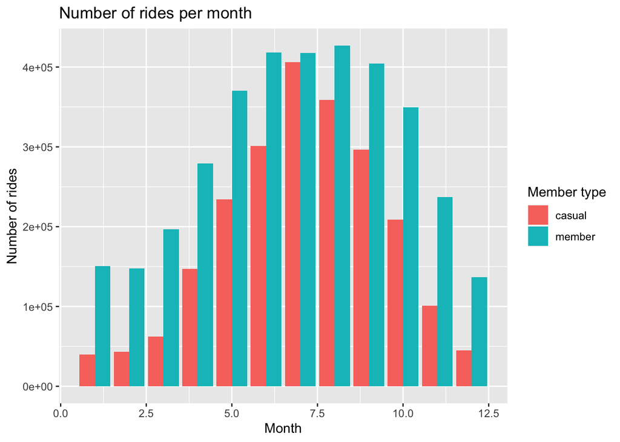

```r
ggplot(data = df) +
  geom_bar(mapping = aes(x = month, fill = member_casual), position = 'dodge')+
  labs(x = 'Month', y = 'Number of rides', fill = 'Member type', title = 'Number of rides per month')
```

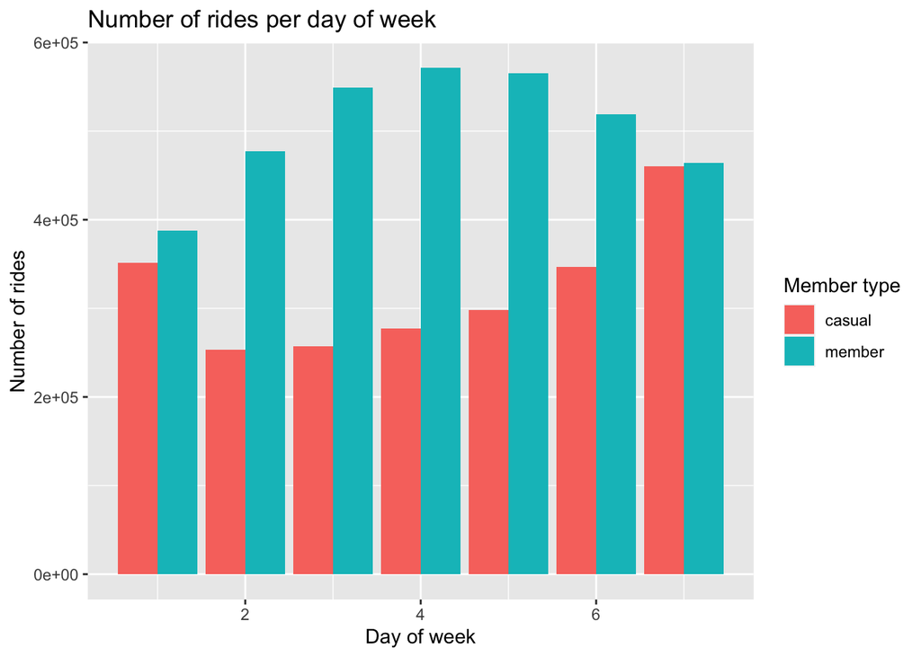

```r
ggplot(data = df) +
  geom_bar(mapping = aes(x = day_of_week, fill = member_casual), position = 'dodge')+
  labs(x = 'Day of week', y = 'Number of rides', fill = 'Member type', title = 'Number of rides per day of week')
```

## Share

### Export data to Tableau

```r
# write.csv(df, file="cleaned_bike_data.csv")
```

**[Link to Tableau Dashboard](https://public.tableau.com/app/profile/ivana.zhao/viz/GoogleDataAnalyticsCapstone_16953506078840/Dashboard1)**

## Act

Based on the dashboard, it seems annual members ride bikes on weekdays more frequently while casual members prefer weekends to ride. Therefore, we could infer that annual members are mainly composed of workers who ride bikes to commute while casual members are mostly tourists or families who ride bikes to enjoy the weekend.

We also noticed that the riding peak happened in summer, including June, July and August. Both casual and annual members prefer electric and classic bikes. Therefore, in terms of marketing strategies, we propose firstly, we could use social medias like Instagram & Facebook to advertise during summer time and focus on electric and classic bike types. Secondly, we could increase the price of single-day & full-day passes to appeal people to upgrade to annual membership. Thirdly, we could lower the price of annual membership during summer time.

Though the dataset is large, some restrictions still exist. For example, if we could have unique user IDs, it would be helpful for us to make some strategies specific to each individual.